# What a Transformative Event Changes

Three models of preference change in a choice panel, and how much a model of observed switching recovers on its own

discrete choice

hidden Markov models

sufficient statistics

causal inference

PyMC

philosophy

Author

Nathaniel Forde

Published

September 12, 2026

L. A. Paul defines a transformative experience as one that changes what you want. Her main example is becoming a parent. You cannot use your present preferences to decide whether to have a child, because having one changes them.

Others have had the experience, and the change shows in what they chose afterwards. Pregnancy is a small case with a date attached. It often changes what people want to eat, and nausea in the first months sends many to plain food. A household that has bought one brand of crackers for years may switch to plain saltines.

This post fits three models to that kind of change and compares what each one reports.

1. **A utility shift.** From the event onwards, the utility of each brand moves by a fixed amount $\Delta$. The change is permanent.
2. **A latent Markov chain.** Each person moves between two hidden preference states, “before” and “after”. The event changes how often they enter “after” and how long they stay. This is a hidden Markov model.
3. **Switching counts.** A person’s purchases form a Markov chain over brands. The event changes the probability of buying each brand after each other brand. The counts of these transitions are sufficient statistics, so the model fits in seconds. It is the funnel model from the [post on sufficient statistics](https://nathanielf.github.io/posts/post-with-code/SufficientStatistics/sufficient_statistics.html).

The first two models describe preferences, which are not observed. The third describes purchases, which are. Each model is fitted to two simulated worlds. In one, the event shifts preferences once and for all. In the other, it changes how people move between two sets of preferences.

The main finding is that the switching counts, which never model a preference, reproduce the population’s response to the event nearly as well as the latent chain does, in both worlds, in seconds rather than a minute or more. The models of preferences are needed for questions about preferences: what a change in price would do, and whether a person’s new choices reflect a lasting change or a passing state.

**Imports, palette, sampler settings**

```python
import os
import sys
import time
import warnings

import numpy as np
import pandas as pd
import pymc as pm
import pytensor
import pytensor.tensor as pt
import arviz as az
import matplotlib.pyplot as plt
from scipy.special import logsumexp, log_softmax

sys.path.insert(0, os.getcwd())
from choice_panel import ALTS, PRICE_IDX, prepare_panel

warnings.filterwarnings("ignore")
pd.set_option("display.precision", 3)
plt.rcParams.update({"figure.dpi": 110, "axes.spines.top": False,
                     "axes.spines.right": False})

PAL = {"grey": "#8a8583", "focal": "#eb6834", "cool": "#2a78d6", "green": "#3a9a5b"}
INK = "#2b2b2b"
MODEL_COL = {"utility shift": PAL["focal"], "latent chain": PAL["cool"], "switching counts": PAL["green"]}
plt.rcParams.update({"axes.edgecolor": "#9a9893", "axes.labelcolor": INK,
                     "xtick.color": "#55534f", "ytick.color": "#55534f",
                     "axes.titlesize": 10, "axes.titlelocation": "left"})
SAMPLE = dict(draws=500, tune=500, chains=2, target_accept=0.9,
              nuts_sampler="numpyro", progressbar=False, random_seed=7)
```

## The Panel

The simulations borrow a real scanner panel of cracker purchases (Jain, Vilcassim and Chintagunta, 1994). It follows 136 households over about twenty purchases each. On each trip a household chooses one of four brands. The data record each brand’s price and whether it was on display or in a store advertisement.

The panel does not record pregnancies. I keep its prices, promotions and number of trips per household, and simulate the choices. The brands are labelled `A` to `D`, and time is counted in trips.

Each household has an **event date** $\tau_n$, a trip between a quarter and three-quarters of the way through its data. In practice the date would come from a recorded birth, moved back to when pregnancy cravings begin. All three models take it as known.

```python
CRACKERS = (
    "/Users/nathanielforde/Documents/Github/bayesian_causal_inference"
    "/bayesian_causal_infer/data/choice_crackers.csv"
)
panel = prepare_panel(pd.read_csv(CRACKERS))
rng_tau = np.random.default_rng(3)
tau = np.round(1 + panel.T_p * rng_tau.uniform(0.25, 0.75, panel.P))   # event trip per person
g = panel.grp_idx
post_event = panel.t >= tau[g]                                          # trip is on or after the event
f"{panel.N} choices, {panel.P} people, median {np.median(panel.T_p):.0f} trips each"
```

```
'3153 choices, 136 people, median 20 trips each'
```

## The Choice Model

Models 1 and 2 share one discrete choice model. Person $n$ on trip $t$ gives brand $j$ the utility

$$U_{njt} = \alpha_j + \beta_n\,\text{price}_{njt} + \theta'x_{njt} + \varepsilon_{njt}.$$

Here $\alpha_j$ is the baseline preference for brand $j$, with $\alpha_D = 0$; $\beta_n$ is the person’s price sensitivity; $\theta$ holds the effects of display and feature promotions $x_{njt}$; and the Gumbel error $\varepsilon$ makes the choice probabilities a softmax of the utilities. Price sensitivities are partially pooled: $\beta_n \sim \text{Normal}(\mu_\beta, \sigma_\beta)$.

The two models differ in what the event does to this utility.

### Model 1: a utility shift

From the event onwards, the utility of each brand moves by a fixed amount:

$$U_{njt} = \alpha_j + \Delta_j\,\mathbb 1[t \ge \tau_n] + \beta_n\,\text{price}_{njt} + \theta'x_{njt} + \varepsilon_{njt}.$$

$\Delta$ is the same for everyone, and the change is permanent. This is an interrupted time series on utilities rather than on purchase shares, so it accounts for prices and promotions.

```python
def utility_shift_logit(panel, y, tau):
    """Choice model with a shared utility shift Delta from each person's event date."""
    after = (panel.t >= tau[panel.grp_idx]).astype(float)
    with pm.Model(coords=panel.coords) as model:
        alphas = pt.concatenate([pm.Normal("alphas_free", 0, 1.5, dims="alts_free"), pt.zeros(1)])
        betas_nr = pm.Normal("betas_nr", 0, 1, dims="normal_covariates")
        mu_price = pm.Normal("mu_price", -2.0, 1.5)
        sigma_price = pm.HalfNormal("sigma_price", 1.0)
        beta_price_n = mu_price + sigma_price * pm.Normal("z_price", 0, 1, dims="person")
        delta = pm.Normal("delta_alpha", 0, 2.5, dims="alts_free")
        delta_full = pt.concatenate([delta, pt.zeros(1)])
        U = (alphas + pt.sum(panel.X[:, :, :PRICE_IDX] * betas_nr, axis=-1)
             + beta_price_n[panel.grp_idx][:, None] * panel.X[:, :, PRICE_IDX]
             + after[:, None] * delta_full)
        pm.Categorical("y", logit_p=U, observed=np.asarray(y))
    return model
```

### Model 2: a latent Markov chain

Each person is in one of two hidden states on each trip, $s_{nt} \in \{\text{before}, \text{after}\}$. In “after”, utilities are shifted by $\Delta$. Between trips the state changes according to the transition matrix

$$\Gamma = \begin{pmatrix} 1-h & h \\ r & 1-r \end{pmatrix}.$$

Rows are the current state and columns the next. $h$ is the probability of entering “after” on a trip, and $r$ the probability of leaving it. In the long run a person spends a share $h/(h+r)$ of trips in “after”, and a spell in “after” lasts $1/r$ trips on average.

The event changes the matrix: $\Gamma^{\text{pre}}$ before $\tau_n$, and $\Gamma^{\text{post}}$ from $\tau_n$ on. Both states are possible on both sides of the event. What changes is the time spent in each. Model 1 is the special case in which $h = 0$ before the event, $h = 1$ at the event, and $r = 0$ throughout.

The states are not observed, so the likelihood sums over every path the states could take. The **forward algorithm** does this one trip at a time. Let $e_{nt}(k)$ be the probability of the choice made on trip $t$ in state $k$, and $f_{nt}(k)$ the probability of person $n$’s choices up to trip $t$, ending in state $k$. Everyone starts in “before”, so $\pi = (1, 0)$:

$$f_{n1}(k) = \pi_k\, e_{n1}(k), \qquad
f_{nt}(k) = e_{nt}(k) \sum_{l} f_{n,t-1}(l)\, \Gamma^{(t)}_{lk}, \qquad
p(y_n) = \sum_k f_{nT_n}(k).$$

$\Gamma^{(t)}$ is the matrix in force on trip $t$. The code runs this recursion with `pytensor.scan`. Households have different numbers of trips, so each is padded to the longest, and a padded trip contributes a probability of one.

The two states can be swapped, along with every parameter, without changing the likelihood. To fix the labels, “after” is the state in which `C` is less preferred, so the shift for `C` is negative. This constrains nothing that is estimated.

```python
def to_grid(panel, values, fill=0.0):
    """One row per trip (N, ...) -> one row per person and trip (P, T_max, ...),
    plus a (P, T_max) mask that is True on real trips."""
    T = int(panel.T_p.max())
    grid = np.full((panel.P, T) + values.shape[1:], fill, dtype=values.dtype)
    trip_idx = panel.t.astype(int) - 1
    grid[panel.grp_idx, trip_idx] = values
    real_trip = np.zeros((panel.P, T), dtype=bool)
    real_trip[panel.grp_idx, trip_idx] = True
    return grid, real_trip


def regime_index(tau, T):
    """(P, T) array: 0 before each person's event, 1 on or after it."""
    return (np.arange(1, T + 1)[None, :] >= np.asarray(tau)[:, None]).astype("int64")


def latent_chain_logit(panel, y, tau):
    """Two-state hidden Markov model with Gamma_pre before each event and Gamma_post after."""
    X, real_trip = to_grid(panel, panel.X)                              # (P, T, J, K)
    Y, _ = to_grid(panel, np.asarray(y).astype("int64"), fill=0)
    regime = regime_index(tau, Y.shape[1])

    with pm.Model(coords={**panel.coords, "regime": ["pre", "post"]}) as model:
        # --- the choice model ---------------------------------------------------
        alphas = pt.concatenate([pm.Normal("alphas_free", 0, 1.5, dims="alts_free"), pt.zeros(1)])
        betas_nr = pm.Normal("betas_nr", 0, 1, dims="normal_covariates")
        mu_price = pm.Normal("mu_price", -2.0, 1.5)
        sigma_price = pm.HalfNormal("sigma_price", 1.0)
        beta_price_n = mu_price + sigma_price * pm.Normal("z_price", 0, 1, dims="person")
        # The shift in 'after'; 'after' is the state in which C is less preferred.
        delta_AB = pm.Normal("delta_AB", 0, 2.5, shape=2)
        delta_C = -pm.HalfNormal("delta_C_size", 5.0, shape=1)
        delta = pm.Deterministic("delta_alpha", pt.concatenate([delta_AB, delta_C]), dims="alts_free")
        delta_full = pt.concatenate([delta, pt.zeros(1)])

        # --- the transition matrices: one (h, r) pair per regime ------------------
        h = pm.Beta("hazard", 1, 4, dims="regime")
        r = pm.Beta("reversion", 1, 4, dims="regime")
        pm.Deterministic("long_run_after", h / (h + r), dims="regime")
        gamma = pt.stack([pt.stack([1 - h, h], axis=-1),
                          pt.stack([r, 1 - r], axis=-1)], axis=-2)          # (regime, 2, 2)
        log_gamma_nt = pt.log(gamma)[regime]                                # (P, T, 2, 2)

        # --- e_nt(k): probability of the observed choice in each state ----------
        U_before = (alphas + pt.sum(X[..., :PRICE_IDX] * betas_nr, axis=-1)
                    + beta_price_n[:, None, None] * X[..., PRICE_IDX])

        def log_prob_of_choice(U):
            return pt.take_along_axis(pm.math.log_softmax(U, axis=-1), Y[..., None], axis=-1)[..., 0]

        log_e = pt.stack([log_prob_of_choice(U_before),
                          log_prob_of_choice(U_before + delta_full)], axis=-1)   # (P, T, 2)
        log_e = pt.where(real_trip[..., None], log_e, 0.0)

        # --- the forward algorithm, in logs --------------------------------------
        log_f_first = np.array([0.0, -np.inf]) + log_e[:, 0]                   # pi = (1, 0)

        def forward_step(log_e_t, log_gamma_t, log_f_prev):
            return pm.math.logsumexp(log_f_prev[:, :, None] + log_gamma_t, axis=1) + log_e_t

        log_f, _ = pytensor.scan(forward_step,
                                 sequences=[log_e[:, 1:].transpose(1, 0, 2),
                                            log_gamma_nt[:, 1:].transpose(1, 0, 2, 3)],
                                 outputs_info=[log_f_first])
        pm.Potential("loglik", pm.math.logsumexp(log_f[-1], axis=-1).sum())
    return model
```

### Model 3: switching counts

The third model has no utilities and no hidden states. The brand bought on trip $t$ depends on the brand bought on trip $t-1$, through a $4 \times 4$ transition matrix $P$. The event changes the matrix from $P^{\text{pre}}$ to $P^{\text{post}}$. The likelihood of all the purchase sequences is

$$\prod_{\text{regimes } m}\ \prod_{i,j} \big(P^{(m)}_{ij}\big)^{N^{(m)}_{ij}},$$

where $N^{(m)}_{ij}$ is the number of times anyone bought brand $j$ right after brand $i$ in regime $m$. These counts are sufficient: two $4 \times 4$ tables replace every purchase sequence. Each row gets a Dirichlet prior and a multinomial likelihood. Two quantities follow from each matrix: the long-run share of each brand (the stationary distribution of the chain), and the probability of buying the same brand twice in a row (the diagonal).

The model does not adjust for prices or promotions. To it, a brand that was on promotion for a month looks the same as a brand people came to prefer.

```python
def transition_counts(panel, y, tau):
    """N[regime, from, to]: purchases of brand j right after brand i, before and after the event."""
    y = np.asarray(y)
    same_person = np.r_[False, panel.grp_idx[1:] == panel.grp_idx[:-1]]
    rows = np.flatnonzero(same_person)                    # trips with a previous trip
    regime = (panel.t[rows] >= tau[panel.grp_idx[rows]]).astype(int)
    N = np.zeros((2, panel.J, panel.J), int)
    np.add.at(N, (regime, y[rows - 1], y[rows]), 1)
    return N


def switching_counts_model(panel, y, tau):
    N = transition_counts(panel, y, tau)
    coords = {"regime": ["pre", "post"], "from": ALTS, "to": ALTS}
    with pm.Model(coords=coords) as model:
        P = pm.Dirichlet("P", a=np.ones((2, panel.J, panel.J)), dims=("regime", "from", "to"))
        pm.Multinomial("N", n=N.sum(-1), p=P, observed=N)
    return model
```

## Two Worlds

Both worlds use the panel’s prices, promotions and trips, the same event dates, and the same preferences before the event: $\alpha = (-1.0, -1.2, 0.6, 0)$ for `A` to `D`, promotion effects $\theta = (0.5, 0.8)$, and price sensitivities $\beta_n \sim \text{Normal}(-2.5, 0.8)$. The typical person buys mostly `C` and `D`. In both worlds the “after” preferences move the utilities by $\Delta = (-2.5, -2.5, -5, 0)$: `C` falls most, and `D`, the plain saltine, gains. The worlds differ in how people reach those preferences.

- **Shift world.** At the event date each person switches to the “after” preferences and stays there. Model 1 is the true model.
- **Moving world.** People move between “before” and “after” on both sides of the event, as in Model 2. Before the event, $(h, r) = (0.05, 0.50)$: people rarely enter “after” and leave within about two trips. From the event, $(h, r) = (0.25, 0.15)$: they enter often and stay about seven trips. The long-run share of trips in “after” rises from 9% to 62%.

|  | shift world | moving world |
| --- | --- | --- |
| “after” preferences | $\alpha + \Delta$ | $\alpha + \Delta$ |
| before the event | always “before” | $h = 0.05$, $r = 0.50$ |
| from the event | always “after” | $h = 0.25$, $r = 0.15$ |
| long-run share in “after”, before / after | 0 / 1 | 0.09 / 0.62 |

Prices and promotions are the same in both worlds and do not change at the event. That makes the comparison fair to the switching counts, which cannot tell a price change from a change in preference.

Choices are simulated in numpy, separately from the PyMC models, so that an error in one is not copied into the other.

```python
DELTA = np.array([-2.5, -2.5, -5.0, 0.0])
HR = {"pre": (0.05, 0.50), "post": (0.25, 0.15)}
rng_truth = np.random.default_rng(31)
truth = dict(alphas=np.array([-1.0, -1.2, 0.6, 0.0]), betas_nr=np.array([0.5, 0.8]),
             beta_price_n=-2.5 + 0.8 * rng_truth.standard_normal(panel.P))


def utilities_before(panel, alphas, betas_nr, beta_price_n):
    """(N, J) utilities in the 'before' state."""
    return (alphas + panel.X[:, :, :PRICE_IDX] @ betas_nr
            + np.asarray(beta_price_n)[panel.grp_idx][:, None] * panel.X[:, :, PRICE_IDX])


def softmax(V):
    V = V - V.max(-1, keepdims=True)
    E = np.exp(V)
    return E / E.sum(-1, keepdims=True)


def draw_choices(p, rng):
    return (p.cumsum(-1) > rng.random(len(p))[:, None]).argmax(-1)


def simulate_states(panel, tau, pre, post, rng):
    """Latent states (N,), from a chain whose (h, r) change at each person's event."""
    state = np.zeros(panel.N, int)
    for i in range(panel.N):                       # rows are sorted by person, then trip
        if panel.t[i] > 1:
            h, r = post if panel.t[i] >= tau[panel.grp_idx[i]] else pre
            state[i] = (rng.random() < h) if state[i - 1] == 0 else (rng.random() >= r)
    return state


def simulate_world(world, seed):
    rng = np.random.default_rng(seed)
    if world == "shift":
        state = post_event.astype(int)
    else:
        state = simulate_states(panel, tau, HR["pre"], HR["post"], rng)
    U = utilities_before(panel, **truth) + state[:, None] * DELTA
    return draw_choices(softmax(U), rng), state


WORLDS = ["shift", "moving"]
data = {w: simulate_world(w, seed) for w, seed in zip(WORLDS, [41, 51])}
pd.DataFrame({w: {"share of trips in 'after', before the event": s[~post_event].mean(),
                  "share of trips in 'after', from the event": s[post_event].mean(),
                  "share buying C, before the event": (y[~post_event] == 2).mean(),
                  "share buying C, from the event": (y[post_event] == 2).mean()}
              for w, (y, s) in data.items()}).round(2)
```

|  | shift | moving |
| --- | --- | --- |
| share of trips in 'after', before the event | 0.00 | 0.08 |
| share of trips in 'after', from the event | 1.00 | 0.55 |
| share buying C, before the event | 0.36 | 0.34 |
| share buying C, from the event | 0.00 | 0.18 |

## Fitting Every Model to Both Worlds

That is six fits, all sampled with NUTS. The counts model could be solved in closed form, since its posterior is a product of Dirichlet distributions, but it is sampled like the others so that the run times are comparable.

```python
MODELS = {"utility shift": utility_shift_logit,
          "latent chain": latent_chain_logit,
          "switching counts": switching_counts_model}
fits, seconds = {}, {}
for world, (y, _) in data.items():
    for name, build in MODELS.items():
        kw = dict(chains=4) if name == "latent chain" else {}
        t0 = time.perf_counter()
        with build(panel, y, tau):
            fits[world, name] = pm.sample(**{**SAMPLE, **kw})
        seconds[world, name] = time.perf_counter() - t0
```

## What Each Model Reports

### The population’s response

The figure aligns everyone on their own event date and shows the share of trips on which `C` was bought. Each model’s line is what its fitted parameters (posterior means) imply for the population, given the observed prices. It does not use each person’s own choices.

- **Utility shift:** the logit probability of `C`, with $\Delta$ added from the event.
- **Latent chain:** the probability of each state on each trip, carried forward from “before” through $\Gamma^{\text{pre}}$ and $\Gamma^{\text{post}}$, times the probability of `C` in that state.
- **Switching counts:** each person’s first purchase, carried forward through $P^{\text{pre}}$ and $P^{\text{post}}$.

```python
def pmean(idata, var):
    return idata.posterior[var].mean(("chain", "draw")).values


def choice_params(idata):
    """Posterior-mean alphas, betas, per-person price slopes and shift."""
    return dict(alphas=np.append(pmean(idata, "alphas_free"), 0.0),
                betas_nr=pmean(idata, "betas_nr"),
                beta_price_n=pmean(idata, "mu_price") + pmean(idata, "sigma_price") * pmean(idata, "z_price"),
                delta=np.append(pmean(idata, "delta_alpha"), 0.0))


def implied_choice_probs(world, name):
    """(N, J) population-level choice probabilities implied by a fitted model."""
    idata = fits[world, name]
    y = data[world][0]
    if name == "switching counts":
        P = pmean(idata, "P")                                  # (regime, J, J)
        probs = np.zeros((panel.N, panel.J))
        for i in range(panel.N):
            if panel.t[i] == 1:
                probs[i] = np.eye(panel.J)[y[i]]               # start from the observed first purchase
            else:
                probs[i] = probs[i - 1] @ P[int(post_event[i])]
        return probs
    cp = choice_params(idata)
    U0 = utilities_before(panel, cp["alphas"], cp["betas_nr"], cp["beta_price_n"])
    p_before, p_after = softmax(U0), softmax(U0 + cp["delta"])
    if name == "utility shift":
        return np.where(post_event[:, None], p_after, p_before)
    h, r = pmean(idata, "hazard"), pmean(idata, "reversion")
    occ = np.zeros(panel.N)                                    # P(after) on each trip, no data used
    for i in range(panel.N):
        if panel.t[i] > 1:
            m = int(post_event[i])
            occ[i] = (1 - occ[i - 1]) * h[m] + occ[i - 1] * (1 - r[m])
    return (1 - occ)[:, None] * p_before + occ[:, None] * p_after


since = (panel.t - tau[g]).astype(int)                         # trips since the event
window = (since >= -8) & (since <= 10)
implied = {(w, m): implied_choice_probs(w, m) for w in WORLDS for m in MODELS}


def by_since(values):
    s = pd.Series(values[window]).groupby(since[window])
    return s.mean(), s.size()
```

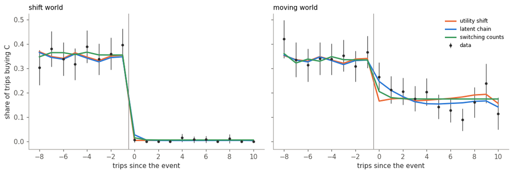

Figure 1: Share of trips on which C was bought, by trips since each person’s event. Points are the simulated data with 89% intervals; lines are each fitted model’s population-level account. Left: the shift world. Right: the moving world.

```python
fig, axs = plt.subplots(1, 2, figsize=(11, 3.8), sharey=True)
for ax, world in zip(axs, WORLDS):
    y = data[world][0]
    share, n = by_since((y == 2).astype(float))
    se = np.sqrt(share * (1 - share) / n)
    ax.errorbar(share.index, share.values, yerr=1.6 * se, fmt="o", color=INK, ms=3, lw=0.8, label="data")
    for name in MODELS:
        m, _ = by_since(implied[world, name][:, 2])
        ax.plot(m.index, m.values, color=MODEL_COL[name], lw=2, label=name)
    ax.axvline(-0.5, color=PAL["grey"], lw=0.8)
    ax.set(xlabel="trips since the event", title=f"{world} world")
    ax.xaxis.set_major_locator(plt.MaxNLocator(integer=True))
axs[0].set_ylabel("share of trips buying C")
axs[1].legend(frameon=False, fontsize=8)
plt.tight_layout();
```

```python
def share_C(world, which, mask):
    vals = (data[world][0] == 2) if which == "data" else implied[world, which][:, 2]
    return vals[mask].mean()


late = post_event & (since >= 6)
NUM = {f"{w}_{k}": f"{share_C(w, k, late):.2f}" for w in WORLDS for k in ["data", *MODELS]}
NUM.update({f"{w}_pre_data": f"{share_C(w, 'data', ~post_event):.2f}" for w in WORLDS})
pd.DataFrame({w: {k: share_C(w, k, late) for k in ["data", *MODELS]} for w in WORLDS}).round(3).rename_axis(
    "share buying C, six or more trips after the event")
```

| share buying C, six or more trips after the event | shift | moving |
| --- | --- | --- |
| data | 0.004 | 0.151 |
| utility shift | 0.005 | 0.178 |
| latent chain | 0.004 | 0.156 |
| switching counts | 0.006 | 0.175 |

In the shift world all three models fit the data. In the moving world the share of `C` falls more slowly and levels off higher, because people keep returning to “before”: six or more trips after the event, `C` is bought on 0.15 of trips, against 0.00 in the shift world.

In the first trips after the event, the latent chain follows the gradual fall most closely. The switching counts follow it partly. The utility shift can only draw a step, so it drops at once to its average level. Six or more trips out, the three models predict 0.16 (latent chain), 0.17 (switching counts) and 0.18 (utility shift). They differ by about two percentage points, well inside the uncertainty in the data.

So for the question “how did the population’s purchases change around the event?”, the switching counts give nearly the same answer as the latent chain, with no model of preferences at all.

### What the utility shift reports

```python
def interval(draws):
    lo, hi = np.quantile(draws, [0.055, 0.945])
    return f"{draws.mean():.2f} [{lo:.2f}, {hi:.2f}]"


def delta_C(world, name):
    return fits[world, name].posterior["delta_alpha"].isel(alts_free=2).values.ravel()


pd.DataFrame({w: {"shift for C (truth −5)": interval(delta_C(w, "utility shift")),
                  "shift for A (truth −2.5)": interval(fits[w, "utility shift"].posterior["delta_alpha"].isel(alts_free=0).values.ravel())}
              for w in WORLDS}).rename_axis("utility shift model, mean [89% interval]")
```

| utility shift model, mean [89% interval] | shift | moving |
| --- | --- | --- |
| shift for C (truth −5) | -5.29 [-5.91, -4.76] | -1.21 [-1.35, -1.06] |
| shift for A (truth −2.5) | -2.42 [-2.81, -2.09] | -1.10 [-1.35, -0.87] |

```python
NUM.update({f"dC_{w}_{m}": f"{delta_C(w, m).mean():.1f}".replace("-", "−") for w in WORLDS for m in ["utility shift", "latent chain"]})
```

In the shift world the utility shift recovers the change for `C`: −5.3 against −5. In the moving world it reports −1.2. People in “after” have the full shift of −5. The estimate is smaller because, after the event, they spend only part of their time in “after”. The model cannot represent that, so it reads less time in the new preferences as a smaller change in preferences.

### What the latent chain reports

```python
TRUE_HR = {"shift": {"pre": (0.0, 0.0), "post": (1.0, 0.0)}, "moving": HR}
rows = []
for w in WORLDS:
    post = fits[w, "latent chain"].posterior
    for reg, when in [("pre", "before the event"), ("post", "from the event")]:
        h_true, r_true = TRUE_HR[w][reg]
        for var, label, true in [("hazard", "h, enter 'after'", h_true),
                                 ("reversion", "r, leave 'after'", r_true),
                                 ("long_run_after", "long-run share in 'after'",
                                  h_true / (h_true + r_true) if h_true + r_true > 0 else 0.0)]:
            rows.append({"world": w, "quantity": f"{label}, {when}",
                         "estimate [89% interval]": interval(post[var].sel(regime=reg).values.ravel()),
                         "truth": true})
    rows.append({"world": w, "quantity": "shift for C",
                 "estimate [89% interval]": interval(delta_C(w, "latent chain")), "truth": -5.0})
pd.DataFrame(rows).set_index(["world", "quantity"])
```

| world | quantity | estimate [89% interval] | truth |
| --- | --- | --- | --- |
| shift | h, enter 'after', before the event | 0.02 [0.00, 0.07] | 0.000 |
|  | r, leave 'after', before the event | 0.43 [0.09, 0.75] | 0.000 |
|  | long-run share in 'after', before the event | 0.03 [0.00, 0.10] | 0.000 |
|  | h, enter 'after', from the event | 0.92 [0.87, 0.97] | 1.000 |
|  | r, leave 'after', from the event | 0.01 [0.00, 0.02] | 0.000 |
|  | long-run share in 'after', from the event | 0.99 [0.98, 1.00] | 1.000 |
|  | shift for C | -7.52 [-11.57, -5.34] | -5.000 |
| moving | h, enter 'after', before the event | 0.06 [0.00, 0.14] | 0.050 |
|  | r, leave 'after', before the event | 0.53 [0.19, 0.78] | 0.500 |
|  | long-run share in 'after', before the event | 0.09 [0.01, 0.17] | 0.091 |
|  | h, enter 'after', from the event | 0.29 [0.23, 0.35] | 0.250 |
|  | r, leave 'after', from the event | 0.18 [0.13, 0.23] | 0.150 |
|  | long-run share in 'after', from the event | 0.61 [0.55, 0.67] | 0.625 |
|  | shift for C | -6.56 [-11.31, -3.59] | -5.000 |

The latent chain tells the two worlds apart. In the moving world it recovers the rates of entering and leaving “after”, before and after the event, and the long-run share of trips in “after”. In the shift world it finds a rate of entering near one at the event and a rate of leaving near zero. That is a permanent switch: Model 1 as a special case of Model 2. Before the event in the shift world no one enters “after”, so $h$ is near zero and $r$, the rate of leaving a state nobody is in, is barely constrained.

The chain estimates the shift for `C` poorly: −7.5 in the shift world and −6.6 in the moving world, against −5, with wide intervals. In “after”, `C` is almost never bought. Any large negative shift explains that, so the data put an upper bound on the shift but no lower bound. The utility shift avoids the problem in the shift world because it is told which trips are “after”. What the chain pins down are the quantities about time: when people enter the new preferences, and how long they stay.

The forward–backward algorithm gives, for each person and trip, the probability of being in “after” given all of that person’s choices. Averaged over people and aligned on the event, it should follow the true share of people in “after”.

```python
def log_emissions(idata, y, n_draws=200):
    """log e_nt(k) for a sample of posterior draws: (draws, P, T, 2). Zero on padded trips."""
    X, real_trip = to_grid(panel, panel.X)
    Y, _ = to_grid(panel, np.asarray(y).astype("int64"), fill=0)
    draws = az.extract(idata, num_samples=n_draws, random_seed=0)
    D = draws.sizes["sample"]
    alphas = np.concatenate([draws["alphas_free"].values.T, np.zeros((D, 1))], axis=1)
    betas = draws["betas_nr"].values.T
    beta_price = (draws["mu_price"].values[:, None]
                  + draws["sigma_price"].values[:, None] * draws["z_price"].values.T)
    shift = np.concatenate([draws["delta_alpha"].values.T, np.zeros((D, 1))], axis=1)
    U0 = (alphas[:, None, None, :] + np.einsum("ptjk,dk->dptj", X[..., :PRICE_IDX], betas)
          + beta_price[:, :, None, None] * X[None, ..., PRICE_IDX])

    def lp(U):
        return np.take_along_axis(log_softmax(U, -1), Y[None, ..., None], -1)[..., 0]

    log_e = np.stack([lp(U0), lp(U0 + shift[:, None, None, :])], axis=-1)
    return np.where(real_trip[None, ..., None], log_e, 0.0), draws


def log_transition(h, r):
    """log [[1-h, h], [r, 1-r]] for arrays of h and r: (..., 2, 2)."""
    return np.log(np.stack([np.stack([1 - h, h], -1), np.stack([r, 1 - r], -1)], -2) + 1e-300)


def after_probs(idata, y, n_draws=200):
    """P(after | all of a person's choices) on each trip, averaged over draws: (P, T)."""
    log_e, draws = log_emissions(idata, y, n_draws)
    h, r = draws["hazard"].values.T, draws["reversion"].values.T          # (draws, regime)
    T = log_e.shape[2]
    log_gamma = log_transition(h, r)[:, regime_index(tau, T)]             # (draws, P, T, 2, 2)
    log_fwd, log_bwd = np.empty_like(log_e), np.zeros_like(log_e)
    log_fwd[:, :, 0] = np.array([0.0, -np.inf]) + log_e[:, :, 0]
    for t in range(1, T):
        log_fwd[:, :, t] = logsumexp(log_fwd[:, :, t - 1, :, None] + log_gamma[:, :, t], axis=2) + log_e[:, :, t]
    for t in range(T - 2, -1, -1):
        log_bwd[:, :, t] = logsumexp(log_gamma[:, :, t + 1]
                                     + (log_e[:, :, t + 1] + log_bwd[:, :, t + 1])[:, :, None, :], axis=3)
    log_post = log_fwd + log_bwd
    log_post -= logsumexp(log_post, axis=-1, keepdims=True)
    return np.exp(log_post[..., 1]).mean(axis=0)


trip_idx = panel.t.astype(int) - 1
p_after = {w: after_probs(fits[w, "latent chain"], data[w][0])[g, trip_idx] for w in WORLDS}
```

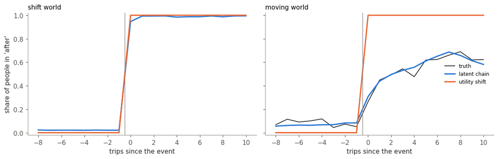

Figure 2: Share of people in the ‘after’ state by trips since the event: the simulated truth, the latent chain’s estimate from each person’s choices (forward–backward), and the utility shift model’s step. Left: the shift world. Right: the moving world.

```python
fig, axs = plt.subplots(1, 2, figsize=(11, 3.6), sharey=True)
for ax, world in zip(axs, WORLDS):
    for label, values, col, lw in [("truth", data[world][1].astype(float), INK, 1.2),
                                   ("latent chain", p_after[world], MODEL_COL["latent chain"], 2),
                                   ("utility shift", post_event.astype(float), MODEL_COL["utility shift"], 2)]:
        m, _ = by_since(values)
        ax.plot(m.index, m.values, color=col, lw=lw, label=label)
    ax.axvline(-0.5, color=PAL["grey"], lw=0.8)
    ax.set(xlabel="trips since the event", title=f"{world} world", ylim=(-0.02, 1.02))
    ax.xaxis.set_major_locator(plt.MaxNLocator(integer=True))
axs[0].set_ylabel("share of people in 'after'")
axs[1].legend(frameon=False, fontsize=8, loc="center right")
plt.tight_layout();
```

```python
correct = {w: np.mean((p_after[w] > 0.5) == (data[w][1] == 1)) for w in WORLDS}
NUM.update({f"correct_{w}": f"{100 * correct[w]:.0f}%" for w in WORLDS})
```

The chain classifies 100% of trips correctly in the shift world and 87% in the moving world. In the moving world a single trip is weaker evidence, because people move in and out of “after”.

### What the switching counts report

The figure shows the fitted transition matrices before and after the event, and the long-run brand shares they imply. In both worlds the long-run share of `C` falls after the event.

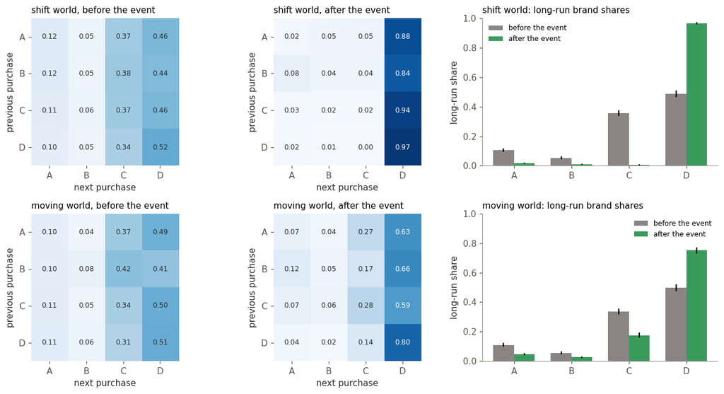

Figure 3: The switching counts model. For each world: the posterior mean probability of buying each brand (columns) right after each brand (rows), before and after the event, and the long-run brand shares implied by each matrix (89% intervals).

```python
def stationary(P):
    """Stationary distribution of each transition matrix in a (..., J, J) array."""
    J = P.shape[-1]
    flat = P.reshape(-1, J, J)
    A = np.concatenate([np.swapaxes(flat, 1, 2) - np.eye(J), np.ones((len(flat), 1, J))], axis=1)
    b = np.r_[np.zeros(J), 1.0]
    return np.stack([np.linalg.lstsq(a, b, rcond=None)[0] for a in A]).reshape(P.shape[:-1])


P_draws = {w: fits[w, "switching counts"].posterior["P"].values.reshape(-1, 2, panel.J, panel.J) for w in WORLDS}
stat = {w: stationary(P_draws[w]) for w in WORLDS}                       # (draws, regime, J)

fig, axs = plt.subplots(2, 3, figsize=(12, 6.4), gridspec_kw={"width_ratios": [1, 1, 1.1]})
for row, world in enumerate(WORLDS):
    for col, (reg, when) in enumerate([(0, "before the event"), (1, "after the event")]):
        ax = axs[row, col]
        M = P_draws[world][:, reg].mean(0)
        ax.imshow(M, cmap="Blues", vmin=0, vmax=1)
        for i in range(panel.J):
            for j in range(panel.J):
                ax.text(j, i, f"{M[i, j]:.2f}", ha="center", va="center", fontsize=8,
                        color="white" if M[i, j] > 0.55 else INK)
        ax.set_xticks(range(panel.J), ALTS)
        ax.set_yticks(range(panel.J), ALTS)
        ax.set(title=f"{world} world, {when}", xlabel="next purchase", ylabel="previous purchase")
        ax.spines[:].set_visible(False)
    ax = axs[row, 2]
    for reg, (off, colour, when) in enumerate([(-0.18, PAL["grey"], "before"), (0.18, PAL["green"], "after")]):
        s = stat[world][:, reg]
        lo, hi = np.quantile(s, [0.055, 0.945], 0)
        ax.bar(np.arange(panel.J) + off, s.mean(0), 0.36, yerr=[s.mean(0) - lo, hi - s.mean(0)],
               color=colour, label=f"{when} the event")
    ax.set_xticks(range(panel.J), ALTS)
    ax.set(ylabel="long-run share", title=f"{world} world: long-run brand shares", ylim=(0, 1))
    ax.legend(frameon=False, fontsize=8)
plt.tight_layout();
```

The rows of each matrix are informative too. In the shift world the rows are nearly identical. The brand bought last time says almost nothing about the brand bought next, because each choice depends only on the current preferences and prices. In the moving world after the event the rows differ: someone who has just bought `D` is more likely to buy it again than someone who has just bought another brand. This is the hidden state persisting from trip to trip, visible in the plain counts.

What the counts cannot do is explain the change. A changed transition matrix may come from changed preferences, from changed prices or promotions, or from both. And a person who now buys `D` may hold new preferences for good or be in a passing state. The counts have no parameter for either distinction.

### A check that separates the worlds: repeat purchases

In the moving world a person in “after” tends to stay there for several trips, so they repeat purchases more often than independent choices with the same probabilities would. The share of trips on which a person buys the same brand as last time is therefore a statistic the utility shift can get wrong and the other two models should get right.

For each fitted model I simulate new choices from 100 posterior draws and record the share of post-event trips that repeat the previous purchase.

```python
has_prev = np.r_[False, g[1:] == g[:-1]]


def repeat_rate(y, mask):
    rows = np.flatnonzero(has_prev & mask)
    return np.mean(y[rows] == y[rows - 1])


def simulate_from(world, name, draw, rng):
    """New choices from one posterior draw of a fitted model."""
    post = fits[world, name].posterior.to_dataset().stack(sample=("chain", "draw")).isel(sample=draw)
    if name == "switching counts":
        P = post["P"].values
        y_obs, y = data[world][0], np.zeros(panel.N, int)
        for i in range(panel.N):
            y[i] = y_obs[i] if panel.t[i] == 1 else draw_choices(P[int(post_event[i]), y[i - 1]][None], rng)[0]
        return y
    alphas = np.append(post["alphas_free"].values, 0.0)
    beta_n = post["mu_price"].values + post["sigma_price"].values * post["z_price"].values
    U0 = utilities_before(panel, alphas, post["betas_nr"].values, beta_n)
    delta = np.append(post["delta_alpha"].values, 0.0)
    if name == "utility shift":
        state = post_event.astype(int)
    else:
        h, r = post["hazard"].values, post["reversion"].values
        state = simulate_states(panel, tau, (h[0], r[0]), (h[1], r[1]), rng)
    return draw_choices(softmax(U0 + state[:, None] * delta), rng)


rng_ppc = np.random.default_rng(0)
ppc = {(w, m): np.array([repeat_rate(simulate_from(w, m, d, rng_ppc), post_event)
                         for d in rng_ppc.choice(fits[w, m].posterior.sizes["draw"] * fits[w, m].posterior.sizes["chain"],
                                                 100, replace=False)])
       for w in WORLDS for m in MODELS}
observed_repeat = {w: repeat_rate(data[w][0], post_event) for w in WORLDS}
```

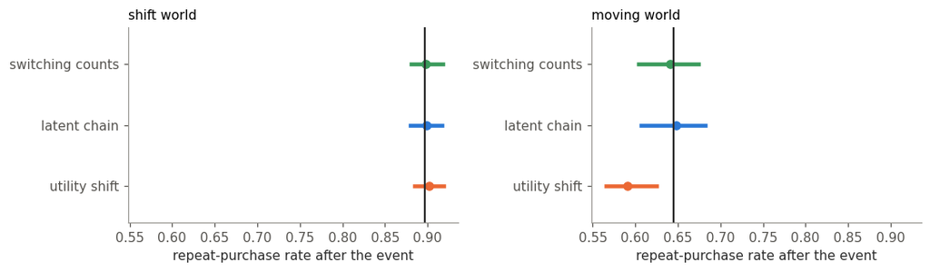

Figure 4: Share of post-event trips on which a person repeats their previous purchase. Black line: the simulated data. Points and bars: each fitted model’s posterior predictive mean and 89% interval. Left: the shift world. Right: the moving world.

```python
fig, axs = plt.subplots(1, 2, figsize=(10, 3.0), sharex=True)
for ax, world in zip(axs, WORLDS):
    for k, name in enumerate(MODELS):
        d = ppc[world, name]
        lo, hi = np.quantile(d, [0.055, 0.945])
        ax.plot([lo, hi], [k, k], color=MODEL_COL[name], lw=3)
        ax.plot(d.mean(), k, "o", color=MODEL_COL[name])
    ax.axvline(observed_repeat[world], color=INK, lw=1.5)
    ax.set_yticks(range(len(MODELS)), list(MODELS))
    ax.set(title=f"{world} world", xlabel="repeat-purchase rate after the event", ylim=(-0.6, 2.6))
plt.tight_layout();
```

```python
NUM.update({f"rep_{w}_data": f"{observed_repeat[w]:.2f}" for w in WORLDS})
NUM.update({f"rep_{w}_{m}": f"{ppc[w, m].mean():.2f}" for w in WORLDS for m in MODELS})
```

In the shift world all three models reproduce the repeat rate. In the moving world the data repeat on 0.64 of post-event trips. The latent chain predicts 0.65 and the switching counts 0.64. The utility shift predicts 0.59, because it treats each trip as an independent choice given prices.

The check needs only the raw purchase sequences. It can therefore tell an analyst who does not know the truth that a permanent utility shift is the wrong model. The counts pass it by construction, since repeat purchases are the diagonal of their transition matrix. They describe the persistence; they do not explain it.

### Cost

```python
pd.DataFrame({w: {m: f"{seconds[w, m]:.0f} s" for m in MODELS} for w in WORLDS}).rename_axis(
    "wall time to compile and sample")
```

| wall time to compile and sample | shift | moving |
| --- | --- | --- |
| utility shift | 9 s | 7 s |
| latent chain | 61 s | 72 s |
| switching counts | 2 s | 1 s |

```python
def seconds_text(x):
    return f"{x:.0f} second" + ("" if round(x) == 1 else "s")


N_shift = transition_counts(panel, data["shift"][0], tau)
NUM.update({"n_trans": f"{N_shift.sum():,}", "n_counts": f"{N_shift.size}",
            "t_counts": seconds_text(np.mean([seconds[w, 'switching counts'] for w in WORLDS])),
            "t_chain": seconds_text(np.mean([seconds[w, 'latent chain'] for w in WORLDS]))})
```

The counts model replaces 3,017 transitions with 32 numbers and fits in about 2 seconds, most of it compilation. The latent chain runs the forward algorithm over every person and trip at every gradient step, and takes about 67 seconds with four chains. Its likelihood cannot be compressed: the hidden state depends on each person’s whole sequence, and its transitions are never observed.

## Conclusion

The three models give three answers to the question of what the event changed.

- **The utility shift** says the event moved the utility function once. It recovers the size of the move when the move is permanent. When people move in and out of the new preferences, it reports a smaller change, because it can represent a change in what people want but not in how often they want it.
- **The latent chain** says the event changed how people move between two sets of preferences. It recovers a permanent switch as a special case, and in the moving world it recovers the rates of entering and leaving the new preferences. It estimates the size of the preference change poorly when one brand is almost never bought in the new state. It is the slowest model, and its likelihood cannot be compressed.
- **The switching counts** say the probabilities of moving between brands changed. From 32 numbers, in seconds, they reproduce the population’s response and its persistence nearly as well as the latent chain. They do not separate preferences from prices, or a lasting change from a passing one.

The practical conclusion is to start with the counts. They show whether and how purchasing changed around the event, and their diagonal shows whether purchases became more persistent. Fit a model of preferences when the question is about preferences: what a change in price would do, or how much of their time people now spend in a new state. In these simulations prices did not change at the event. Where they do, the counts may attribute a price effect to the event, and the choice models become necessary.

Paul’s argument is about what a person can know before a transformative experience. This post is about what an observer can learn afterwards. From about twenty choices per person and a known event date, an observer can tell a permanent change in preferences from a change in how often a person holds them. Becoming a parent probably fits the second description better than the first. It does not fix a person’s preferences in a new position; it changes how often, and for how long, they act on a new set of them.